```python
import pandas as pd
import numpy as np
import warnings
import matplotlib.pyplot as plt

# Suprimir todos os warnings
warnings.filterwarnings("ignore")
```

# Ler Arquivo

O caminho para os arquivo CSV na máquina usada é "D:\Python\finance\Absolute\Dados\20240120_Casos_e_obitos_ESP\tmp\tmpi0lf4neq\20240120_Casos_e_obitos_ESP.csv"

Caso, necessário realizar ajustes no caminho.

```python
path = "D:\\Python\\finance\\Absolute\\Dados\\20240120_Casos_e_obitos_ESP\\tmp\\tmpi0lf4neq\\20240120_Casos_e_obitos_ESP.csv"
```

```python
df = pd.read_csv(path,
                 sep = ';', # Separador usando ';' como parâmetro
                 header=0)  # Define-se a linha 0 como index.
```

```python
display(df)
```

|  | Asma | Cardiopatia | Data_Inicio_Sintomas | Diabetes | Diagnostico_Covid19 | Doenca_Hematologica | Doenca_Hepatica | Doenca_Neurologica | Doenca Renal | Genero | Idade | Imunodepressao | Municipio | Obesidade | Obito | Outros_Fatores_De_Risco | Pneumopatia | Puérpera | Síndrome_De_Down |
| --- | --- | --- | --- | --- | --- | --- | --- | --- | --- | --- | --- | --- | --- | --- | --- | --- | --- | --- | --- |
| 0 | IGNORADO | IGNORADO | 15/07/2022 | IGNORADO | CONFIRMADO | IGNORADO | IGNORADO | IGNORADO | IGNORADO | MASCULINO | 69.0 | IGNORADO | ASSIS | IGNORADO | 0 | IGNORADO | IGNORADO | IGNORADO | IGNORADO |
| 1 | IGNORADO | IGNORADO | 21/02/2021 | IGNORADO | CONFIRMADO | IGNORADO | IGNORADO | IGNORADO | IGNORADO | FEMININO | 60.0 | IGNORADO | SÃO PAULO | IGNORADO | 0 | IGNORADO | IGNORADO | IGNORADO | IGNORADO |
| 2 | IGNORADO | IGNORADO | 23/06/2021 | IGNORADO | CONFIRMADO | IGNORADO | IGNORADO | IGNORADO | IGNORADO | MASCULINO | 58.0 | IGNORADO | ARARAQUARA | IGNORADO | 0 | IGNORADO | IGNORADO | IGNORADO | IGNORADO |
| 3 | IGNORADO | IGNORADO | 03/02/2021 | IGNORADO | CONFIRMADO | IGNORADO | IGNORADO | IGNORADO | IGNORADO | FEMININO | 45.0 | IGNORADO | SÃO PAULO | IGNORADO | 0 | IGNORADO | IGNORADO | IGNORADO | IGNORADO |
| 4 | IGNORADO | IGNORADO | 23/02/2021 | IGNORADO | CONFIRMADO | IGNORADO | IGNORADO | IGNORADO | IGNORADO | FEMININO | 42.0 | IGNORADO | SÃO PAULO | IGNORADO | 0 | IGNORADO | IGNORADO | IGNORADO | IGNORADO |
| ... | ... | ... | ... | ... | ... | ... | ... | ... | ... | ... | ... | ... | ... | ... | ... | ... | ... | ... | ... |
| 6770923 | IGNORADO | IGNORADO | 11/01/2022 | IGNORADO | CONFIRMADO | IGNORADO | IGNORADO | IGNORADO | IGNORADO | MASCULINO | 1.0 | IGNORADO | SÃO BERNARDO DO CAMPO | IGNORADO | 0 | IGNORADO | IGNORADO | IGNORADO | IGNORADO |
| 6770924 | IGNORADO | IGNORADO | 18/05/2021 | IGNORADO | CONFIRMADO | IGNORADO | IGNORADO | IGNORADO | IGNORADO | MASCULINO | 9.0 | IGNORADO | ITAQUAQUECETUBA | IGNORADO | 0 | IGNORADO | IGNORADO | IGNORADO | IGNORADO |
| 6770925 | IGNORADO | IGNORADO | 02/01/2023 | IGNORADO | CONFIRMADO | IGNORADO | IGNORADO | IGNORADO | IGNORADO | MASCULINO | 0.0 | IGNORADO | CAMPINAS | IGNORADO | 0 | IGNORADO | IGNORADO | IGNORADO | IGNORADO |
| 6770926 | NÃO | SIM | 10/05/2020 | SIM | CONFIRMADO | NÃO | NÃO | NÃO | NÃO | FEMININO | 77.0 | NÃO | SÃO PAULO | NÃO | 1 | IGNORADO | NÃO | NÃO | NÃO |
| 6770927 | IGNORADO | IGNORADO | 07/03/2021 | IGNORADO | CONFIRMADO | IGNORADO | IGNORADO | IGNORADO | IGNORADO | MASCULINO | 35.0 | IGNORADO | SANTO ANDRÉ | IGNORADO | 0 | IGNORADO | IGNORADO | IGNORADO | IGNORADO |

6770928 rows × 19 columns

## Análise Exploratória dos Dados

Obter informações sobre o arquivo CSV

```python
df.info()
```

```
<class 'pandas.core.frame.DataFrame'>
RangeIndex: 6770928 entries, 0 to 6770927
Data columns (total 19 columns):
 #   Column                   Dtype
---  ------                   -----
 0   Asma                     object
 1   Cardiopatia              object
 2   Data_Inicio_Sintomas     object
 3   Diabetes                 object
 4   Diagnostico_Covid19      object
 5   Doenca_Hematologica      object
 6   Doenca_Hepatica          object
 7   Doenca_Neurologica       object
 8   Doenca Renal             object
 9   Genero                   object
 10  Idade                    float64
 11  Imunodepressao           object
 12  Municipio                object
 13  Obesidade                object
 14  Obito                    int64
 15  Outros_Fatores_De_Risco  object
 16  Pneumopatia              object
 17  Puérpera                 object
 18  Síndrome_De_Down         object
dtypes: float64(1), int64(1), object(17)
memory usage: 981.5+ MB
```

Confirmando informações.

```python
n_linhas, n_colunas = df.shape
print(f"Linhas: {n_linhas}")
print(f"Colunas: {n_colunas}")
```

```
Linhas: 6770928
Colunas: 19
```

Variável com o nome das colunas:

```python
colunas = df.columns # Se quiser usar tolist()
print(colunas)
```

```
Index(['Asma', 'Cardiopatia', 'Data_Inicio_Sintomas', 'Diabetes',
       'Diagnostico_Covid19', 'Doenca_Hematologica', 'Doenca_Hepatica',
       'Doenca_Neurologica', 'Doenca Renal', 'Genero', 'Idade',
       'Imunodepressao', 'Municipio', 'Obesidade', 'Obito',
       'Outros_Fatores_De_Risco', 'Pneumopatia', 'Puérpera',
       'Síndrome_De_Down'],
      dtype='object')
```

### Descobrindo o número de linhas vazias.

```python
df.isna().sum()
```

```
Asma                            0
Cardiopatia                     0
Data_Inicio_Sintomas       244724
Diabetes                        0
Diagnostico_Covid19             0
Doenca_Hematologica             0
Doenca_Hepatica                 0
Doenca_Neurologica              0
Doenca Renal                    0
Genero                          1
Idade                      221457
Imunodepressao                  0
Municipio                       0
Obesidade                       0
Obito                           0
Outros_Fatores_De_Risco         0
Pneumopatia                     0
Puérpera                        0
Síndrome_De_Down                0
dtype: int64
```

Estudo sobre as colunas "Data_Inicio_Sintomas", "Idade" e "Genero"

```python
filtro_data = df[df["Data_Inicio_Sintomas"].isna()]
print(filtro_data.shape)
```

```
(244724, 19)
```

```python
filtro_data_idade = filtro_data[filtro_data['Idade'].isna()]
print(filtro_data_idade.shape)
```

```
(214413, 19)
```

É o observado que nos 244.724 casos em que é NaN na coluna "Data_Inicio_Sintomas", temos 214.413 linhas com NaN na coluna "Idade" também.

```python
filtro_data_idade_genero = filtro_data_idade[filtro_data_idade['Genero'].isna()]
print(filtro_data_idade_genero.shape)
```

```
(0, 19)
```

```python
filtro_data_genero = filtro_data[filtro_data['Genero'].isna()]
print(filtro_data_genero.shape)
```

```
(0, 19)
```

```python
filtro_idade_genero = df[df['Idade'].isna() & df['Genero'].isna()]
print(filtro_idade_genero.shape)
```

```
(0, 19)
```

# 1 - Existe diferença de incidência de COVID entre homens e mulheres?

# 2 - Faça um gráfico da mortalidade por faixas de idade.

É preciso definar as faixas estárias, segue a divisão:

Infantil: 0 - 12 anos

Adolescente: 13 - 17 anos

Adulto: 18 - 64 anos

Idoso : +65 anos

```python
def ler_csv(path=None):
    # Caso não informado o path, usar o caminho padrão da máquina.
    if path is None:
        path = "D:\\Python\\finance\\Absolute\\Dados\\20240120_Casos_e_obitos_ESP\\tmp\\tmpi0lf4neq\\20240120_Casos_e_obitos_ESP.csv"

    # Usando a estrutura try e except para ler o arquivo.
    try:
        df = pd.read_csv(path,
                         sep = ';', # Separador usando ';' como parâmetro
                         header=0)  # Define-se a linha 0 como index.
        return df

    except Exception as e:
        print(f"Ocorreu um erro ao ler o arquivo: {e}")
        return None
```

```python
exercio_2 = ler_csv()
exercio_2.head()
```

|  | Asma | Cardiopatia | Data_Inicio_Sintomas | Diabetes | Diagnostico_Covid19 | Doenca_Hematologica | Doenca_Hepatica | Doenca_Neurologica | Doenca Renal | Genero | Idade | Imunodepressao | Municipio | Obesidade | Obito | Outros_Fatores_De_Risco | Pneumopatia | Puérpera | Síndrome_De_Down |
| --- | --- | --- | --- | --- | --- | --- | --- | --- | --- | --- | --- | --- | --- | --- | --- | --- | --- | --- | --- |
| 0 | IGNORADO | IGNORADO | 15/07/2022 | IGNORADO | CONFIRMADO | IGNORADO | IGNORADO | IGNORADO | IGNORADO | MASCULINO | 69.0 | IGNORADO | ASSIS | IGNORADO | 0 | IGNORADO | IGNORADO | IGNORADO | IGNORADO |
| 1 | IGNORADO | IGNORADO | 21/02/2021 | IGNORADO | CONFIRMADO | IGNORADO | IGNORADO | IGNORADO | IGNORADO | FEMININO | 60.0 | IGNORADO | SÃO PAULO | IGNORADO | 0 | IGNORADO | IGNORADO | IGNORADO | IGNORADO |
| 2 | IGNORADO | IGNORADO | 23/06/2021 | IGNORADO | CONFIRMADO | IGNORADO | IGNORADO | IGNORADO | IGNORADO | MASCULINO | 58.0 | IGNORADO | ARARAQUARA | IGNORADO | 0 | IGNORADO | IGNORADO | IGNORADO | IGNORADO |
| 3 | IGNORADO | IGNORADO | 03/02/2021 | IGNORADO | CONFIRMADO | IGNORADO | IGNORADO | IGNORADO | IGNORADO | FEMININO | 45.0 | IGNORADO | SÃO PAULO | IGNORADO | 0 | IGNORADO | IGNORADO | IGNORADO | IGNORADO |
| 4 | IGNORADO | IGNORADO | 23/02/2021 | IGNORADO | CONFIRMADO | IGNORADO | IGNORADO | IGNORADO | IGNORADO | FEMININO | 42.0 | IGNORADO | SÃO PAULO | IGNORADO | 0 | IGNORADO | IGNORADO | IGNORADO | IGNORADO |

Será realizado os seguintes tratamentos:

Excluir as linhas que não apresentam dados na coluna "Idade"

Adicionar uma nova coluna com nome de "Faixa_Etaria"

Classificar cada linha de acordo com as Faixas Etárias equivalentes

Realizar o calculo do número de casos por Faixa Etária e o número de mortes por Faixa Etária

Plotar o gráfico dos dados obtidos

## Tratamento da Coluna "Idade" removendo as linhas NaN.

```python
def tratamento_coluna_idade(df_dados):

    # Realizar o tratamento de excluir as linhas que são vazias na coluna 'Idade'
    try:
        # Verificar se a coluna 'Idade' existe no DataFrame
        if 'Idade' not in df_dados.columns:
            raise KeyError("A coluna 'Idade' não existe no DataFrame.")

        # Excluir linhas com NaN na coluna 'Idade'
        df_dados = df_dados.dropna(subset=['Idade']).reset_index(drop=True)

    except KeyError as e:
        print(f"Erro de chave: {e}")
    except Exception as e:
        print(f"Ocorreu um erro ao realizar o tratamento dos dados: {e}")

    return df_dados
```

```python
novo_exercio_2 = tratamento_coluna_idade(df_dados=exercio_2)
novo_exercio_2.isna().sum()
```

```
Asma                           0
Cardiopatia                    0
Data_Inicio_Sintomas       30311
Diabetes                       0
Diagnostico_Covid19            0
Doenca_Hematologica            0
Doenca_Hepatica                0
Doenca_Neurologica             0
Doenca Renal                   0
Genero                         1
Idade                          0
Imunodepressao                 0
Municipio                      0
Obesidade                      0
Obito                          0
Outros_Fatores_De_Risco        0
Pneumopatia                    0
Puérpera                       0
Síndrome_De_Down               0
dtype: int64
```

Não temos mais nenhuma linha da coluna "Idade" sem dados, agora seguiremos para o tratamento de inserir a nova coluna "Faixa_Etaria" e preenche-la

## Preenchendo a nova coluna "Faixa_Etaria"

```python
def coluna_faixa_etaria(df_dados):
    '''
    Adicionar a nova coluna Faixa_Etaria com NaN
    '''
    try:
        # Fazer uma cópia do DataFrame para evitar modificar o original
        df_dados = df_dados.copy()

        # Verificar se a coluna 'Idade' existe no DataFrame
        if 'Idade' not in df_dados.columns:
            raise KeyError("A coluna 'Idade' não existe no DataFrame.")

        df_dados['Faixa_Etaria'] = np.nan

        '''
        Realizar o preenchimento da coluna Faixa_Etaria.
        Considerar a seguinte classificação:
        Infantil:      0 - 12 anos
        Adolescente:   13 - 17 anos
        Adulto:        18 - 64 anos
        Idoso :        +65 anos

        Prencher as linhas da seguinte maneira:
        Infantil = 0
        Adolescente = 1
        Adulto = 2
        Idoso = 3
        '''
        '''
        for i in range(0, len(df_dados)):
            # Obtemos o elemento da coluna "Idade" na lina "i".
            posicao_i = df_dados['Idade'].iloc[i]

            if posicao_i >= 0 and posicao_i <= 12:
                df_dados['Faixa_Etaria'].iloc[i] = 0
            elif posicao_i >= 13 and posicao_i <= 17:
                df_dados['Faixa_Etaria'].iloc[i] = 1
            elif posicao_i >= 18 and posicao_i <= 64:
                df_dados['Faixa_Etaria'].iloc[i] = 2
            else:
                df_dados['Faixa_Etaria'].iloc[i] = 3
        '''
        # Função auxiliar para categorizar a faixa etária
        def categorizar_faixa_etaria(idade):
            if pd.isna(idade):
                return np.nan
            elif idade >= 0 and idade <= 12:
                return 0
            elif idade >= 13 and idade <= 17:
                return 1
            elif idade >= 18 and idade <= 64:
                return 2
            elif idade >= 65:
                return 3
            else:
                return np.nan

        # Aplicar a função auxiliar a cada valor da coluna 'Idade'
        df_dados['Faixa_Etaria'] = df_dados['Idade'].apply(categorizar_faixa_etaria)

        # Converter os valores para inteiros
        df_dados['Faixa_Etaria'] = df_dados['Faixa_Etaria'].astype(int)

    except KeyError as e:
        print(f"Erro de chave: {e}")

    except Exception as e:
        print(f"Ocorreu um erro ao adicionar a coluna 'Faixa_Etaria': {e}")

    return df_dados
```

```python
novo_exercicio_2_faixa = coluna_faixa_etaria(novo_exercio_2)
```

```python
novo_exercicio_2_faixa.tail()
```

|  | Asma | Cardiopatia | Data_Inicio_Sintomas | Diabetes | Diagnostico_Covid19 | Doenca_Hematologica | Doenca_Hepatica | Doenca_Neurologica | Doenca Renal | Genero | Idade | Imunodepressao | Municipio | Obesidade | Obito | Outros_Fatores_De_Risco | Pneumopatia | Puérpera | Síndrome_De_Down | Faixa_Etaria |
| --- | --- | --- | --- | --- | --- | --- | --- | --- | --- | --- | --- | --- | --- | --- | --- | --- | --- | --- | --- | --- |
| 6770923 | IGNORADO | IGNORADO | 11/01/2022 | IGNORADO | CONFIRMADO | IGNORADO | IGNORADO | IGNORADO | IGNORADO | MASCULINO | 1.0 | IGNORADO | SÃO BERNARDO DO CAMPO | IGNORADO | 0 | IGNORADO | IGNORADO | IGNORADO | IGNORADO | 0 |
| 6770924 | IGNORADO | IGNORADO | 18/05/2021 | IGNORADO | CONFIRMADO | IGNORADO | IGNORADO | IGNORADO | IGNORADO | MASCULINO | 9.0 | IGNORADO | ITAQUAQUECETUBA | IGNORADO | 0 | IGNORADO | IGNORADO | IGNORADO | IGNORADO | 0 |
| 6770925 | IGNORADO | IGNORADO | 02/01/2023 | IGNORADO | CONFIRMADO | IGNORADO | IGNORADO | IGNORADO | IGNORADO | MASCULINO | 0.0 | IGNORADO | CAMPINAS | IGNORADO | 0 | IGNORADO | IGNORADO | IGNORADO | IGNORADO | 0 |
| 6770926 | NÃO | SIM | 10/05/2020 | SIM | CONFIRMADO | NÃO | NÃO | NÃO | NÃO | FEMININO | 77.0 | NÃO | SÃO PAULO | NÃO | 1 | IGNORADO | NÃO | NÃO | NÃO | 3 |
| 6770927 | IGNORADO | IGNORADO | 07/03/2021 | IGNORADO | CONFIRMADO | IGNORADO | IGNORADO | IGNORADO | IGNORADO | MASCULINO | 35.0 | IGNORADO | SANTO ANDRÉ | IGNORADO | 0 | IGNORADO | IGNORADO | IGNORADO | IGNORADO | 2 |

Estudar os dados obtidos, focando no número de Obitos por Faixa Etária.

```python
# Divisão da coluna "Obito" para cada caracter da coluna "Faixa_Etaria"
dados_gerados = novo_exercicio_2_faixa.groupby('Faixa_Etaria')['Obito'].value_counts()
print(dados_gerados)
```

```
Faixa_Etaria  Obito
0             0         333655
              1            371
1             0         218849
              1            163
2             0        5170247
              1          75221
3             0         644369
              1         106596
Name: Obito, dtype: int64
```

```python
novo_exercicio_2_faixa.groupby('Faixa_Etaria')['Obito'].agg(['count', 'sum'])
```

| Faixa_Etaria | count | sum |
| --- | --- | --- |
| 0 | 334026 | 371 |
| 1 | 219012 | 163 |
| 2 | 5245468 | 75221 |
| 3 | 750965 | 106596 |

```python
sorted(novo_exercicio_2_faixa['Faixa_Etaria'].unique())
```

```
[0, 1, 2, 3]
```

## Função para obter a Contagem dos Casos e Óbitos por Faixa de Idade

```python
def contagem_faixa_obito(df_dados):
    # Obtendo as faixas etárias únicas em ordem
    faixas_etarias = sorted(novo_exercicio_2_faixa['Faixa_Etaria'].unique())

    # Criando um DataFrame vazio para armazenar os resultados
    dados_faixa_etaria = pd.DataFrame(columns=['Faixa_Etaria', 'N_Casos', 'N_Obitos'])

    # Iterando sobre as faixas etárias
    for j in faixas_etarias:
        # Inicializando as contagens
        contagem = 0
        contagem_obitos = 0

        # Iterando sobre as linhas do DataFrame
        for i in range(0, len(df_dados)):
            # Verificando se a faixa etária na linha atual corresponde à faixa etária atual do loop externo
            if df_dados['Faixa_Etaria'].iloc[i] == j:
                contagem += 1
                if df_dados['Obito'].iloc[i] == 1:
                    contagem_obitos += 1

        # Adicionando os resultados para a faixa etária atual ao DataFrame de resultados
        dados_faixa_etaria = dados_faixa_etaria.append({'Faixa_Etaria': j,
                                                        'N_Casos': contagem,
                                                        'N_Obitos': contagem_obitos},
                                                       ignore_index=True)
        '''
        dados_faixa_etaria['Faixa_Etaria'] = j
        dados_faixa_etaria['N_Casos'] = contagem
        dados_faixa_etaria['N_Obitos'] = contagem_obitos
        '''

    return dados_faixa_etaria
```

```python
dados_faixa_etaria = contagem_faixa_obito(df_dados=novo_exercicio_2_faixa)
```

Tenhos os dados do Número de Casos e Óbitos para cada Faixa Etária, próximo passo é plotar o gráfico.

```python
display(dados_faixa_etaria)
```

|  | Faixa_Etaria | N_Casos | N_Obitos |
| --- | --- | --- | --- |
| 0 | 0 | 334026 | 371 |
| 1 | 1 | 219012 | 163 |
| 2 | 2 | 5245468 | 75221 |
| 3 | 3 | 750965 | 106596 |

## Plotar o Gráfico

```python
def plotar_grafico(df_dados):
    # Mapeamento dos números de faixa etária para os intervalos de idade
    mapeamento_faixa_etaria = {
        0: '0 - 12 anos',
        1: '13 - 17 anos',
        2: '18 - 64 anos',
        3: '+65 anos'
    }

    # Fazendo uma cópia do DataFrame para evitar modificar o original
    df_dados = df_dados.copy()

    # Substituir os números de faixa etária pelos intervalos de idade correspondentes
    df_dados['Faixa_Etaria'] = df_dados['Faixa_Etaria'].map(mapeamento_faixa_etaria)

    #Adicionar a coluna "Taxa_Mortalidade"
    df_dados['Taxa_Mortalidade'] = (df_dados['N_Obitos'] / df_dados['N_Casos']) * 100
    #print(df_dados)

    # Cores para cada barra
    #cores = ['blue', 'orange', 'green', 'red']

    plt.figure(figsize=(8, 6))
    bars = plt.bar(df_dados['Faixa_Etaria'], df_dados['Taxa_Mortalidade'], color= 'darkblue')
    plt.xlabel('Faixa Etária')
    plt.ylabel('Taxa de Mortalidade (%)')
    plt.title('Taxa de Mortalidade por Faixa Etária')
    plt.grid(axis='y',  which="both")

    # Adicionando as porcentagens acima das barras
    for bar in bars:
        height = bar.get_height()
        plt.text(bar.get_x() + bar.get_width() / 2, height, f'{height:.2f}%', ha='center', va='bottom', fontsize=10)

    # Configurando a escala do eixo Y em logaritmo
    plt.yscale('log')
    plt.yticks([0.1, 1, 10], ['0.1', '1', '10'])  # Define os rótulos personalizados

    plt.show()
```

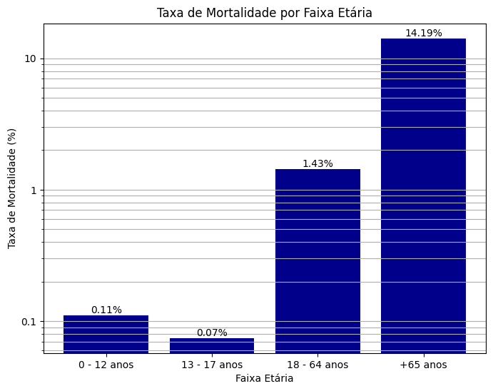

```python
plotar_grafico(dados_faixa_etaria)
```

# 3 - Qual a doença pré-existente mais provável de se encontrar numa pessoa com COVID?

# 4 - Baseado nesses dados, faça um modelo que estime a probabilidade de uma pessoa morrer, uma vez que está contaminada com COVID, e considerando os inputs de **idade**, **gênero** e **doenças pré-existentes**.